# Extra-innings Baserunner

Exploratory data analysis of the extra-innings baserunner on second base.

Author

[Christian Hicks](https://github.com/hicks017)

Published

May 3, 2025

Modified

May 7, 2025

## Setup

**Packages**

```r
library(readr)
library(dplyr)
library(skimr)
library(ggplot2)
library(broom)
```

**Data**

```r
# Use a flexible route to the file path
if (basename(getwd()) == "explore data") {
  path <- "../resources/data"
} else if (basename(getwd()) == "MLB-rule-changes") {
  path <- "resources/data"
} else {print("Failed to set path")}

df_extras <- read_csv(file.path(path, "extra_innings_games.csv"))
```

## Total extra innings

**Prepare data**

```r
# Change name for Cleveland to the Guardians
df_extras <- mutate(
  df_extras,
  team_winner = ifelse(
    endsWith(team_winner, "Indians"),
    "Cleveland Guardians",
    team_winner
  ),
  team_loser = ifelse(
    endsWith(team_loser, "Indians"),
    "Cleveland Guardians",
    team_loser
  )
)

# Count innings over 9 per game per year
df_extras <-
  df_extras |>
  mutate(extras = final_inning - 9) |>

  # Add indication of rule change and change year to a factor
  mutate(rule_change = ifelse(year < 2020, FALSE, TRUE)) |>
  mutate(year = factor(year))
```

How many extra innings were required to complete a game over the years?

```r
# Summarize by year
df_extras |>
  select(year, extras) |>
  group_by(year) |>
  skimr::skim() |>
  skimr::yank("numeric")
```

**Variable type: numeric**

| skim_variable | year | n_missing | complete_rate | mean | sd | p0 | p25 | p50 | p75 | p100 | hist |
| --- | --- | --- | --- | --- | --- | --- | --- | --- | --- | --- | --- |
| extras | 2014 | 0 | 1 | 2.36 | 1.64 | 1 | 1 | 2 | 3.00 | 10 | ▇▃▁▁▁ |
| extras | 2015 | 0 | 1 | 2.23 | 1.51 | 1 | 1 | 2 | 3.00 | 10 | ▇▃▁▁▁ |
| extras | 2016 | 0 | 1 | 2.30 | 1.59 | 1 | 1 | 2 | 3.00 | 10 | ▇▃▁▁▁ |
| extras | 2017 | 0 | 1 | 2.07 | 1.56 | 1 | 1 | 2 | 2.00 | 10 | ▇▂▁▁▁ |
| extras | 2018 | 0 | 1 | 2.20 | 1.52 | 1 | 1 | 2 | 3.00 | 8 | ▇▂▂▁▁ |
| extras | 2019 | 0 | 1 | 2.29 | 1.79 | 1 | 1 | 2 | 3.00 | 10 | ▇▂▁▁▁ |
| extras | 2020 | 0 | 1 | 1.42 | 0.74 | 1 | 1 | 1 | 2.00 | 4 | ▇▂▁▁▁ |
| extras | 2021 | 0 | 1 | 1.39 | 0.74 | 1 | 1 | 1 | 2.00 | 7 | ▇▁▁▁▁ |
| extras | 2022 | 0 | 1 | 1.39 | 0.75 | 1 | 1 | 1 | 2.00 | 6 | ▇▁▁▁▁ |
| extras | 2023 | 0 | 1 | 1.37 | 0.75 | 1 | 1 | 1 | 1.75 | 5 | ▇▂▁▁▁ |
| extras | 2024 | 0 | 1 | 1.40 | 0.80 | 1 | 1 | 1 | 1.50 | 5 | ▇▂▁▁▁ |

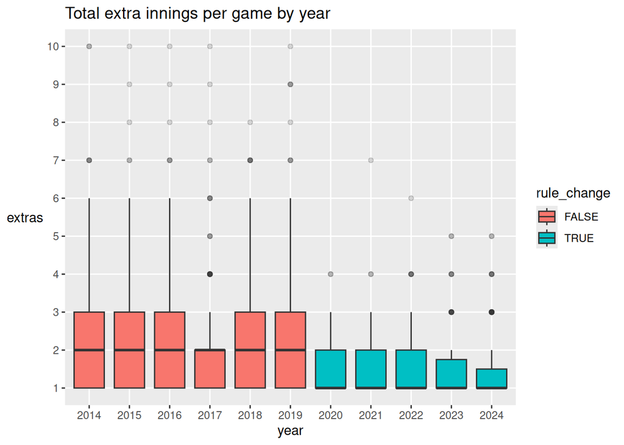

```r
# Visualize
ggplot(df_extras, aes(x = year, y = extras, fill = rule_change)) +
  geom_boxplot(outlier.alpha = 0.2) +
  scale_y_continuous(breaks = seq(0, 10, by = 1)) +
  theme(
    panel.grid.minor = element_blank(),
    axis.title.y = element_text(angle=0, vjust = 0.5)
  ) +
  ggtitle("Total extra innings per game by year")
```

```r
# t test
t.test(extras ~ rule_change, data = df_extras) |>
  tidy() |>
  rename(pre_2020 = estimate1, post_2020 = estimate2)
```

| estimate | pre_2020 | post_2020 | statistic | p.value | parameter | conf.low | conf.high | method | alternative |
| --- | --- | --- | --- | --- | --- | --- | --- | --- | --- |
| 0.8573681 | 2.246019 | 1.388651 | 16.6049 | 0 | 1891.678 | 0.7561036 | 0.9586326 | Welch Two Sample t-test | two.sided |

Number of extra innings required to complete a game decreased by just under 1 inning after the rule change.

## Total runs in extra innings

How many runs were scored during extra innings?

```r
# Summarize by year
df_extras |>
  select(year, total_extra_runs) |>
  group_by(year) |>
  skimr::skim() |>
  skimr::yank("numeric")
```

**Variable type: numeric**

| skim_variable | year | n_missing | complete_rate | mean | sd | p0 | p25 | p50 | p75 | p100 | hist |
| --- | --- | --- | --- | --- | --- | --- | --- | --- | --- | --- | --- |
| total_extra_runs | 2014 | 0 | 1 | 1.90 | 1.48 | 1 | 1 | 1 | 2 | 10 | ▇▂▁▁▁ |
| total_extra_runs | 2015 | 0 | 1 | 1.80 | 1.35 | 1 | 1 | 1 | 2 | 9 | ▇▂▁▁▁ |
| total_extra_runs | 2016 | 0 | 1 | 1.74 | 1.26 | 1 | 1 | 1 | 2 | 8 | ▇▁▁▁▁ |
| total_extra_runs | 2017 | 0 | 1 | 2.00 | 1.44 | 1 | 1 | 1 | 3 | 9 | ▇▃▁▁▁ |
| total_extra_runs | 2018 | 0 | 1 | 1.83 | 1.37 | 1 | 1 | 1 | 2 | 7 | ▇▁▁▁▁ |
| total_extra_runs | 2019 | 0 | 1 | 2.02 | 1.63 | 1 | 1 | 1 | 3 | 8 | ▇▂▁▁▁ |
| total_extra_runs | 2020 | 0 | 1 | 2.65 | 1.67 | 1 | 1 | 3 | 3 | 7 | ▇▆▂▁▂ |
| total_extra_runs | 2021 | 0 | 1 | 2.91 | 2.23 | 1 | 1 | 3 | 4 | 12 | ▇▂▁▁▁ |
| total_extra_runs | 2022 | 0 | 1 | 2.75 | 1.96 | 1 | 1 | 3 | 4 | 11 | ▇▂▁▁▁ |
| total_extra_runs | 2023 | 0 | 1 | 2.70 | 1.81 | 1 | 1 | 3 | 3 | 8 | ▇▅▂▁▁ |
| total_extra_runs | 2024 | 0 | 1 | 2.79 | 2.23 | 1 | 1 | 2 | 4 | 11 | ▇▂▁▁▁ |

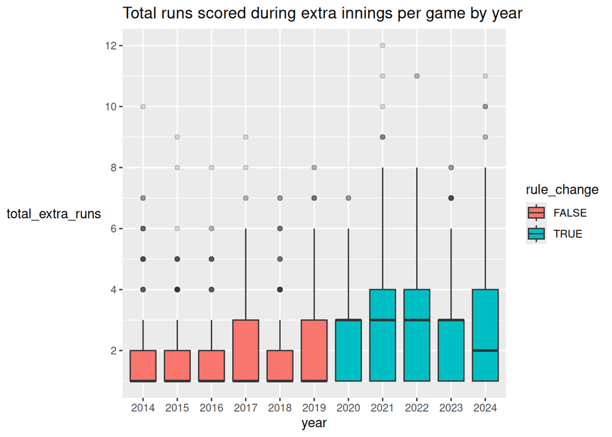

```r
# Visualize
ggplot(df_extras, aes(x = year, y = total_extra_runs, fill = rule_change)) +
  geom_boxplot(outlier.alpha = 0.2) +
  scale_y_continuous(breaks = seq(0, 12, by = 2)) +
  theme(
    axis.title.y = element_text(angle=0, vjust = 0.5)
  ) +
  ggtitle("Total runs scored during extra innings per game by year")
```

```r
# t test
t.test(total_extra_runs ~ rule_change, data = df_extras) |>
  tidy() |>
  rename(pre_2020 = estimate1, post_2020 = estimate2)
```

| estimate | pre_2020 | post_2020 | statistic | p.value | parameter | conf.low | conf.high | method | alternative |
| --- | --- | --- | --- | --- | --- | --- | --- | --- | --- |
| -0.8959325 | 1.881369 | 2.777302 | -11.4816 | 0 | 1582.575 | -1.04899 | -0.7428754 | Welch Two Sample t-test | two.sided |

Number of runs scored during extra innings per game game increased by almost 1 run after the rule change. The median increased by 2 runs.

## Batters until first score

How many batters appear before the first run is scored in extra innings?

```r
# Summarize by year
df_extras |>
  select(year, batters_until_first_run) |>
  group_by(year) |>
  skimr::skim() |>
  skimr::yank("numeric")
```

**Variable type: numeric**

| skim_variable | year | n_missing | complete_rate | mean | sd | p0 | p25 | p50 | p75 | p100 | hist |
| --- | --- | --- | --- | --- | --- | --- | --- | --- | --- | --- | --- |
| batters_until_first_run | 2014 | 0 | 1 | 14.60 | 11.74 | 1 | 6 | 11 | 20.00 | 87 | ▇▃▁▁▁ |
| batters_until_first_run | 2015 | 0 | 1 | 13.35 | 10.16 | 1 | 6 | 11 | 17.50 | 63 | ▇▃▂▁▁ |
| batters_until_first_run | 2016 | 0 | 1 | 14.45 | 12.13 | 1 | 5 | 11 | 19.00 | 74 | ▇▃▁▁▁ |
| batters_until_first_run | 2017 | 0 | 1 | 12.63 | 11.05 | 1 | 5 | 10 | 16.00 | 69 | ▇▃▁▁▁ |
| batters_until_first_run | 2018 | 0 | 1 | 14.05 | 11.22 | 1 | 5 | 10 | 20.00 | 58 | ▇▃▂▁▁ |
| batters_until_first_run | 2019 | 0 | 1 | 13.22 | 11.80 | 1 | 5 | 10 | 16.75 | 62 | ▇▃▁▁▁ |
| batters_until_first_run | 2020 | 0 | 1 | 5.72 | 5.19 | 1 | 2 | 4 | 8.00 | 27 | ▇▂▁▁▁ |
| batters_until_first_run | 2021 | 0 | 1 | 5.20 | 4.74 | 1 | 2 | 4 | 7.00 | 45 | ▇▁▁▁▁ |
| batters_until_first_run | 2022 | 0 | 1 | 5.21 | 4.77 | 1 | 2 | 4 | 7.00 | 28 | ▇▂▁▁▁ |
| batters_until_first_run | 2023 | 0 | 1 | 4.91 | 3.86 | 1 | 2 | 4 | 7.00 | 23 | ▇▃▁▁▁ |
| batters_until_first_run | 2024 | 0 | 1 | 4.95 | 3.80 | 1 | 2 | 4 | 7.00 | 26 | ▇▂▁▁▁ |

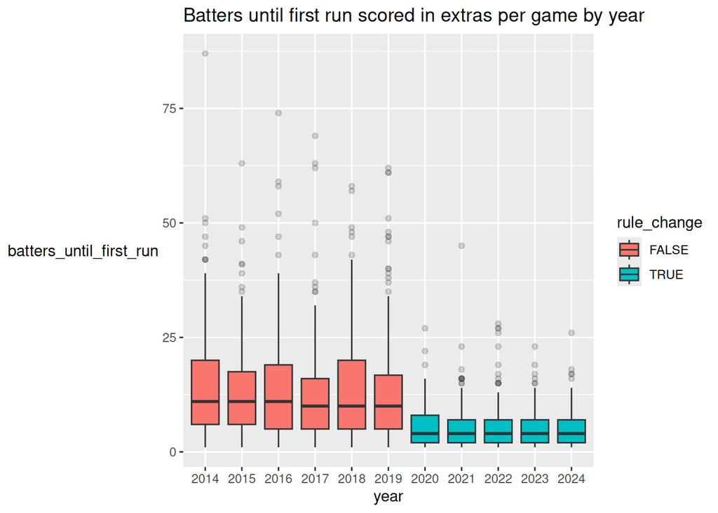

```r
# Visualize
ggplot(df_extras, aes(x = year, y = batters_until_first_run, fill = rule_change)) +
  geom_boxplot(outlier.alpha = 0.2) +
  theme(axis.title.y = element_text(angle=0, vjust = 0.5)) +
  ggtitle("Batters until first run scored in extras per game by year")
```

```r
# t test
t.test(batters_until_first_run ~ rule_change, data = df_extras) |>
  tidy() |>
  rename(pre_2020 = estimate1, post_2020 = estimate2)
```

| estimate | pre_2020 | post_2020 | statistic | p.value | parameter | conf.low | conf.high | method | alternative |
| --- | --- | --- | --- | --- | --- | --- | --- | --- | --- |
| 8.631705 | 13.74841 | 5.116702 | 24.56899 | 0 | 1716.78 | 7.942635 | 9.320776 | Welch Two Sample t-test | two.sided |

Number of batters until first run scored during extra innings per game decreased by more than 8 after the rule change.

Note that the 25th percentile dropped from 5-6 to 2 batters, and the 75th percentile dropped from 16-20 to 7. Additionally, outlying games dropped from 40-60 to 13-30 These are quite big changes.

## Marathon games

Defining marathon games as those in the 95th percentile for a given season.

**Prepare data**

```r
# Select the games at and above the 75th percentile for final inning, by season
tbl_marathons <-
  df_extras |>
  group_by(year) |>
  filter(final_inning >= quantile(final_inning, probs = 0.95, na.rm = TRUE)) |>
  ungroup()
```

### Final inning

What does extra innings count, runs in extras, and batters until first run look like in each season’s longest games?

```r
# Summarize 95th percentile of final inning
tbl_marathons |>
  group_by(year) |>
  select(final_inning) |>
  skimr::skim() |>
  skimr::yank("numeric")
```

**Variable type: numeric**

| skim_variable | year | n_missing | complete_rate | mean | sd | p0 | p25 | p50 | p75 | p100 | hist |
| --- | --- | --- | --- | --- | --- | --- | --- | --- | --- | --- | --- |
| final_inning | 2014 | 0 | 1 | 14.81 | 1.42 | 14 | 14.00 | 14.0 | 15.00 | 19 | ▇▂▁▁▁ |
| final_inning | 2015 | 0 | 1 | 15.21 | 1.72 | 14 | 14.00 | 14.0 | 16.00 | 19 | ▇▂▁▁▁ |
| final_inning | 2016 | 0 | 1 | 15.43 | 1.65 | 14 | 14.00 | 15.0 | 16.00 | 19 | ▇▃▁▁▁ |
| final_inning | 2017 | 0 | 1 | 15.67 | 1.61 | 14 | 14.75 | 15.0 | 16.25 | 19 | ▇▂▁▁▁ |
| final_inning | 2018 | 0 | 1 | 14.89 | 0.99 | 14 | 14.00 | 15.0 | 16.00 | 17 | ▇▃▁▅▁ |
| final_inning | 2019 | 0 | 1 | 16.12 | 1.41 | 15 | 15.00 | 15.5 | 17.25 | 19 | ▇▃▁▃▁ |
| final_inning | 2020 | 0 | 1 | 12.33 | 0.52 | 12 | 12.00 | 12.0 | 12.75 | 13 | ▇▁▁▁▃ |
| final_inning | 2021 | 0 | 1 | 12.38 | 1.02 | 12 | 12.00 | 12.0 | 12.00 | 16 | ▇▁▁▁▁ |
| final_inning | 2022 | 0 | 1 | 12.47 | 0.80 | 12 | 12.00 | 12.0 | 13.00 | 15 | ▇▃▁▁▁ |
| final_inning | 2023 | 0 | 1 | 12.50 | 0.73 | 12 | 12.00 | 12.0 | 13.00 | 14 | ▇▁▃▁▂ |
| final_inning | 2024 | 0 | 1 | 12.39 | 0.66 | 12 | 12.00 | 12.0 | 13.00 | 14 | ▇▁▂▁▁ |

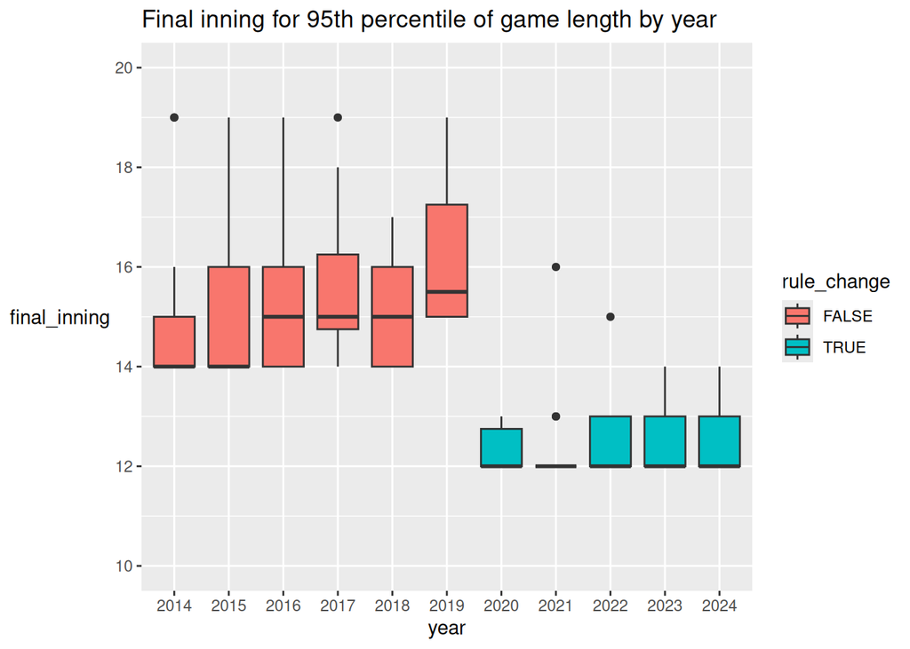

```r
# Visualize 95th percentile of final inning
ggplot(tbl_marathons, aes(x = year, y = final_inning, fill = rule_change)) +
  geom_boxplot() +
  scale_y_continuous(limits = c(10, 20), breaks = seq(10, 20, by = 2)) +
  theme(axis.title.y = element_text(angle=0, vjust = 0.5)) +
  ggtitle("Final inning for 95th percentile of game length by year")
```

```r
# t test
t.test(final_inning ~ rule_change, data = tbl_marathons) |>
  tidy() |>
  rename(pre_2020 = estimate1, post_2020 = estimate2)
```

| estimate | pre_2020 | post_2020 | statistic | p.value | parameter | conf.low | conf.high | method | alternative |
| --- | --- | --- | --- | --- | --- | --- | --- | --- | --- |
| 2.851433 | 15.27451 | 12.42308 | 16.66601 | 0 | 157.9713 | 2.513509 | 3.189357 | Welch Two Sample t-test | two.sided |

The mean final inning of the 95th percentile of each season decreased by nearly 3 innings after the rule change.

### Total runs

How many runs were scored in marathon games across the seasons?

```r
# Summarize by year
tbl_marathons |>
  select(year, total_extra_runs) |>
  group_by(year) |>
  skimr::skim() |>
  skimr::yank("numeric")
```

**Variable type: numeric**

| skim_variable | year | n_missing | complete_rate | mean | sd | p0 | p25 | p50 | p75 | p100 | hist |
| --- | --- | --- | --- | --- | --- | --- | --- | --- | --- | --- | --- |
| total_extra_runs | 2014 | 0 | 1 | 2.15 | 1.70 | 1 | 1.0 | 1.0 | 3.00 | 7 | ▇▂▁▁▁ |
| total_extra_runs | 2015 | 0 | 1 | 2.50 | 1.65 | 1 | 1.0 | 2.0 | 3.75 | 5 | ▇▂▂▁▃ |
| total_extra_runs | 2016 | 0 | 1 | 2.14 | 1.29 | 1 | 1.0 | 2.0 | 3.00 | 5 | ▇▃▃▁▁ |
| total_extra_runs | 2017 | 0 | 1 | 2.67 | 2.27 | 1 | 1.0 | 2.5 | 3.00 | 9 | ▇▇▁▁▁ |
| total_extra_runs | 2018 | 0 | 1 | 3.00 | 1.70 | 1 | 1.5 | 3.0 | 3.50 | 7 | ▆▇▂▁▂ |
| total_extra_runs | 2019 | 0 | 1 | 2.69 | 1.85 | 1 | 1.0 | 3.0 | 3.00 | 8 | ▆▇▁▁▁ |
| total_extra_runs | 2020 | 0 | 1 | 2.17 | 1.33 | 1 | 1.0 | 2.0 | 3.00 | 4 | ▇▁▁▅▂ |
| total_extra_runs | 2021 | 0 | 1 | 6.06 | 1.81 | 3 | 5.0 | 6.0 | 7.00 | 10 | ▂▇▇▁▂ |
| total_extra_runs | 2022 | 0 | 1 | 4.41 | 3.02 | 1 | 3.0 | 3.0 | 7.00 | 11 | ▇▂▁▂▁ |
| total_extra_runs | 2023 | 0 | 1 | 4.56 | 2.03 | 1 | 3.0 | 4.0 | 7.00 | 7 | ▁▇▁▂▇ |
| total_extra_runs | 2024 | 0 | 1 | 5.26 | 2.60 | 1 | 3.0 | 5.0 | 7.00 | 10 | ▂▇▇▆▃ |

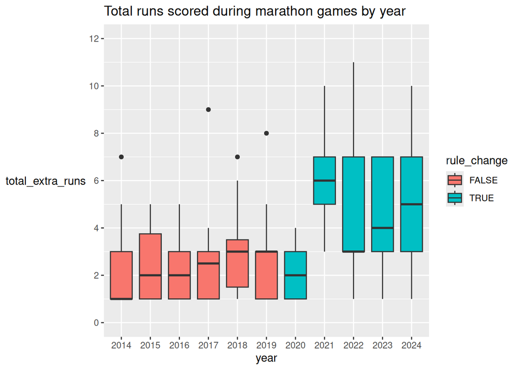

```r
# Visualize
ggplot(tbl_marathons, aes(x = year, y = total_extra_runs, fill = rule_change)) +
  geom_boxplot() +
  scale_y_continuous(limits = c(0, 12), breaks = seq(0, 12, by = 2)) +
  theme(axis.title.y = element_text(angle=0, vjust = 0.5)) +
  ggtitle("Total runs scored during marathon games by year")
```

```r
# t test
t.test(total_extra_runs ~ rule_change, data = tbl_marathons) |>
  tidy() |>
  rename(pre_2020 = estimate1, post_2020 = estimate2)
```

| estimate | pre_2020 | post_2020 | statistic | p.value | parameter | conf.low | conf.high | method | alternative |
| --- | --- | --- | --- | --- | --- | --- | --- | --- | --- |
| -2.358974 | 2.5 | 4.858974 | -7.081945 | 0 | 129.8023 | -3.017976 | -1.699972 | Welch Two Sample t-test | two.sided |

Total runs during marathon games increased by slightly more than 2 runs after the rule change.

### Batters until first score

```r
# Summarize by year
tbl_marathons |>
  select(year, batters_until_first_run) |>
  group_by(year) |>
  skimr::skim() |>
  skimr::yank("numeric")
```

**Variable type: numeric**

| skim_variable | year | n_missing | complete_rate | mean | sd | p0 | p25 | p50 | p75 | p100 | hist |
| --- | --- | --- | --- | --- | --- | --- | --- | --- | --- | --- | --- |
| batters_until_first_run | 2014 | 0 | 1 | 36.22 | 14.37 | 10 | 32.00 | 35.0 | 42.00 | 87 | ▃▇▃▁▁ |
| batters_until_first_run | 2015 | 0 | 1 | 31.57 | 17.10 | 2 | 22.25 | 33.0 | 41.00 | 63 | ▅▃▅▇▂ |
| batters_until_first_run | 2016 | 0 | 1 | 43.00 | 14.58 | 13 | 36.00 | 39.0 | 50.75 | 74 | ▂▆▇▅▂ |
| batters_until_first_run | 2017 | 0 | 1 | 37.67 | 21.81 | 1 | 29.00 | 36.5 | 53.00 | 69 | ▆▁▇▃▆ |
| batters_until_first_run | 2018 | 0 | 1 | 39.11 | 10.04 | 20 | 33.50 | 38.0 | 45.00 | 58 | ▂▇▇▅▂ |
| batters_until_first_run | 2019 | 0 | 1 | 41.88 | 13.91 | 17 | 35.00 | 43.0 | 48.75 | 62 | ▆▁▆▇▅ |
| batters_until_first_run | 2020 | 0 | 1 | 17.00 | 7.21 | 8 | 11.50 | 17.5 | 21.25 | 27 | ▇▁▇▃▃ |
| batters_until_first_run | 2021 | 0 | 1 | 12.56 | 10.90 | 1 | 4.75 | 11.0 | 16.00 | 45 | ▇▇▁▁▁ |
| batters_until_first_run | 2022 | 0 | 1 | 11.35 | 11.20 | 1 | 2.00 | 3.0 | 23.00 | 28 | ▇▁▁▁▅ |
| batters_until_first_run | 2023 | 0 | 1 | 9.56 | 7.24 | 1 | 2.75 | 10.0 | 15.25 | 23 | ▇▂▃▃▂ |
| batters_until_first_run | 2024 | 0 | 1 | 9.52 | 6.38 | 1 | 3.50 | 9.0 | 13.50 | 26 | ▆▇▂▂▁ |

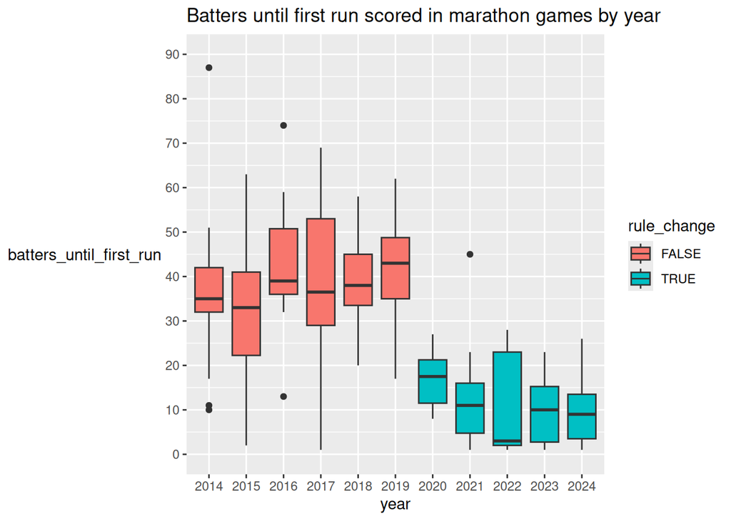

```r
# Visualize
ggplot(tbl_marathons, aes(x = year, y = batters_until_first_run, fill = rule_change)) +
  geom_boxplot() +
  scale_y_continuous(limits = c(0, 90), breaks = seq(0, 90, by = 10)) +
  theme(axis.title.y = element_text(angle=0, vjust = 0.5)) +
  ggtitle("Batters until first run scored in marathon games by year")
```

```r
# t test
t.test(batters_until_first_run ~ rule_change, data = tbl_marathons) |>
  tidy() |>
  rename(pre_2020 = estimate1, post_2020 = estimate2)
```

| estimate | pre_2020 | post_2020 | statistic | p.value | parameter | conf.low | conf.high | method | alternative |
| --- | --- | --- | --- | --- | --- | --- | --- | --- | --- |
| 26.97964 | 38.10784 | 11.12821 | 14.94435 | 0 | 167.7511 | 23.41552 | 30.54375 | Welch Two Sample t-test | two.sided |

Batter appearances until first score decreased by 27 after the rule change.